# CPUE project 2

Beth Babcock

2025-11-20

```r
library(tidyverse)
library(glmmTMB)
library(MuMIn)
library(DHARMa)
theme_set(theme_bw())
```

1.Use the same SWO data we used in the last assignment. Fit a Tweedie model to the CPUE (SWO/set) and used dredge to find the best set of predictor variables. Look at the DHARMa residuals. Does it fit well?

```r
obsdat<-read_csv("obsdatSwo.csv")%>%
  mutate(Year=factor(Year),
         season=factor(season),
         area=factor(area),
         cpue=SWO/sets)
summary(obsdat)
```

```
##       Year      area     season       lat               lon
##  1994   : 104   N: 983   1:605   Min.   :-47.500   Min.   :-81.50
##  1996   : 102   S:1000   2:475   1st Qu.:-11.500   1st Qu.:-27.50
##  1990   :  89            3:384   Median : -0.500   Median :-17.50
##  1991   :  89            4:519   Mean   :  1.998   Mean   :-16.19
##  1995   :  86                    3rd Qu.: 14.500   3rd Qu.:  2.00
##  2004   :  85                    Max.   : 49.500   Max.   : 19.50
##  (Other):1428
##       hbf             BUM               SWO              sets           fleet
##  Min.   : 3.00   Min.   :  0.000   Min.   :  0.00   Min.   : 1.00   Min.   :2
##  1st Qu.:10.00   1st Qu.:  0.000   1st Qu.:  7.00   1st Qu.:11.00   1st Qu.:2
##  Median :10.00   Median :  2.000   Median : 21.00   Median :20.00   Median :2
##  Mean   :14.98   Mean   :  6.933   Mean   : 29.88   Mean   :19.88   Mean   :2
##  3rd Qu.:24.00   3rd Qu.:  8.000   3rd Qu.: 38.00   3rd Qu.:20.00   3rd Qu.:2
##  Max.   :24.00   Max.   :140.000   Max.   :364.00   Max.   :99.00   Max.   :2
##
##       cpue
##  Min.   :0.0000
##  1st Qu.:0.6962
##  Median :1.3333
##  Mean   :1.4959
##  3rd Qu.:2.0000
##  Max.   :9.0000
##
```

```r
Tweedie1<-glmmTMB(cpue~Year+area+season,
                  data=obsdat,
                  family="tweedie",
                  na.action="na.fail")
TweedieDredge<-dredge(Tweedie1,
                      rank="BIC")
```

```
## Fixed terms are "cond((Int))" and "disp((Int))"
```

```r
head(TweedieDredge)
```

```
## Global model call: glmmTMB(formula = cpue ~ Year + area + season, data = obsdat,
##     family = "tweedie", na.action = "na.fail", ziformula = ~0,
##     dispformula = ~1)
## ---
## Model selection table
##   cnd((Int)) dsp((Int)) cnd(are) cnd(ssn) cnd(Yer) df    logLik    BIC  delta
## 2     0.2330          +        +                    4 -2800.449 5631.3   0.00
## 4     0.2820          +        +        +           7 -2793.545 5640.2   8.97
## 6     0.3272          +        +                 + 32 -2724.945 5692.8  61.58
## 8     0.3608          +        +        +        + 35 -2717.498 5700.7  69.46
## 1     0.4027          +                             3 -2848.691 5720.2  88.89
## 3     0.4298          +                 +           6 -2843.722 5733.0 101.73
##   weight
## 2  0.989
## 4  0.011
## 6  0.000
## 8  0.000
## 1  0.000
## 3  0.000
## Models ranked by BIC(x)
```

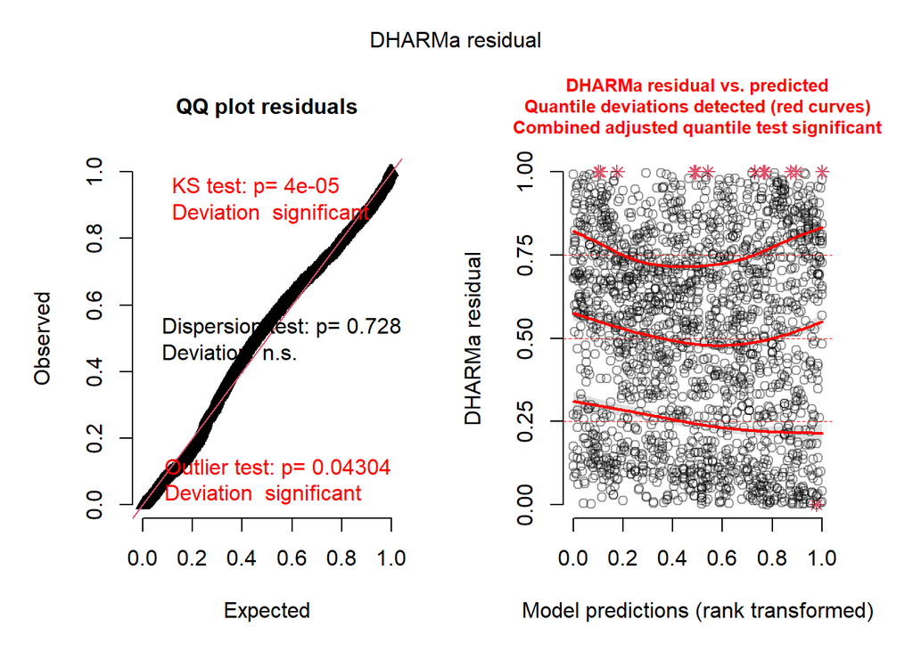

```r
TweedieBest<-get.models(TweedieDredge,subset=4)[[1]]  #Select best with a year effect
plot(simulateResiduals(TweedieBest))
```

```r
summary(TweedieBest)
```

```
##  Family: tweedie  ( log )
## Formula:          cpue ~ area + season + Year + 1
## Data: obsdat
##
##       AIC       BIC    logLik -2*log(L)  df.resid
##    5505.0    5700.7   -2717.5    5435.0      1948
##
##
## Dispersion parameter for tweedie family (): 0.582
##
## Conditional model:
##             Estimate Std. Error z value Pr(>|z|)
## (Intercept)  0.36076    0.07380   4.888 1.02e-06 ***
## areaS        0.29014    0.03108   9.336  < 2e-16 ***
## season2     -0.02061    0.04141  -0.498 0.618725
## season3     -0.01708    0.04403  -0.388 0.698084
## season4     -0.14509    0.04095  -3.543 0.000396 ***
## Year1991     0.16433    0.09520   1.726 0.084303 .
## Year1992     0.33002    0.09982   3.306 0.000946 ***
## Year1993     0.21971    0.09639   2.279 0.022653 *
## Year1994     0.16403    0.09220   1.779 0.075250 .
## Year1995     0.19904    0.09588   2.076 0.037897 *
## Year1996    -0.17313    0.09769  -1.772 0.076350 .
## Year1997    -0.15727    0.10587  -1.485 0.137416
## Year1998    -0.18829    0.10375  -1.815 0.069542 .
## Year1999    -0.14393    0.10465  -1.375 0.169028
## Year2000    -0.09111    0.10235  -0.890 0.373337
## Year2001     0.05437    0.10950   0.497 0.619536
## Year2002    -0.00788    0.10944  -0.072 0.942598
## Year2003    -0.32911    0.10871  -3.027 0.002467 **
## Year2004    -0.17523    0.10287  -1.703 0.088490 .
## Year2005    -0.17964    0.11386  -1.578 0.114624
## Year2006    -0.20178    0.10733  -1.880 0.060105 .
## Year2007    -0.29527    0.11047  -2.673 0.007518 **
## Year2008    -0.24258    0.10646  -2.279 0.022689 *
## Year2009    -0.23807    0.11455  -2.078 0.037681 *
## Year2010    -0.36487    0.11992  -3.043 0.002346 **
## Year2011    -0.21736    0.11821  -1.839 0.065949 .
## Year2012    -0.03393    0.11317  -0.300 0.764292
## Year2013    -0.11299    0.12282  -0.920 0.357589
## Year2014    -0.35056    0.12823  -2.734 0.006261 **
## Year2015    -0.12818    0.13038  -0.983 0.325534
## Year2016    -0.15395    0.13039  -1.181 0.237720
## Year2017    -0.07973    0.12370  -0.645 0.519238
## Year2018    -0.31921    0.12797  -2.494 0.012619 *
## ---
## Signif. codes:  0 '***' 0.001 '**' 0.01 '*' 0.05 '.' 0.1 ' ' 1
```

2. Plot the predicted mean CPUE per year plus and minus SE for the negative binomial 2 fit from the last assignment and the Tweedie you just fit. How similar are they?

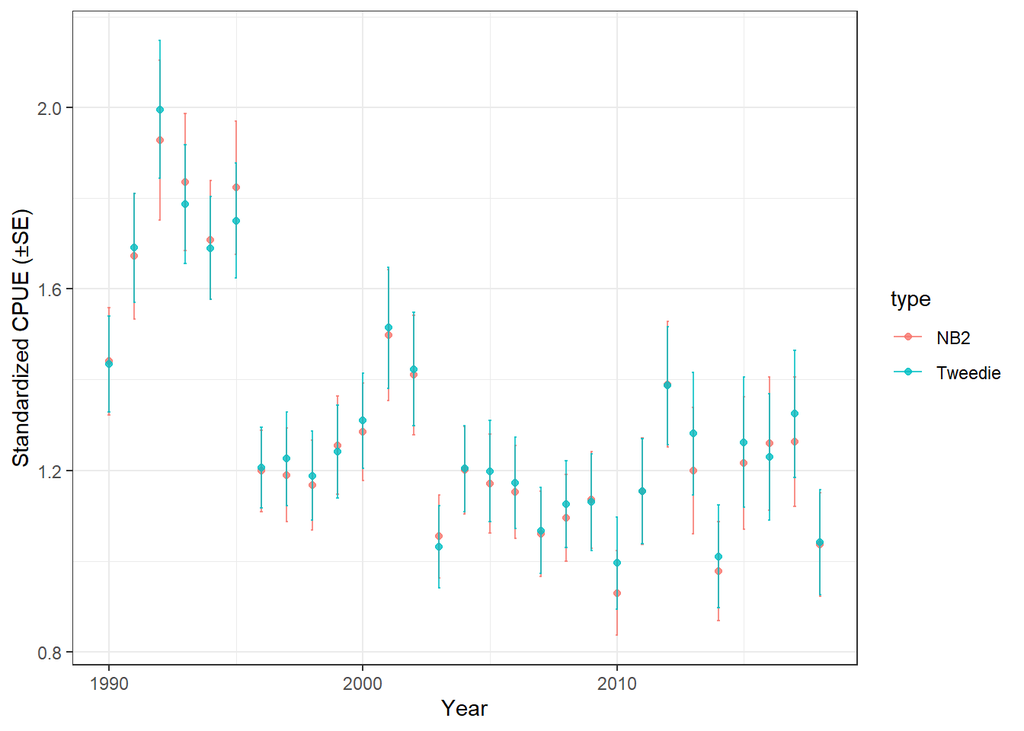

```r
NB2<-glmmTMB(SWO~Year+area+season+offset(log(sets)),
                  data=obsdat,
                  family="nbinom2")
newdata1<-newdata2<-expand.grid(Year=factor(levels(obsdat$Year)),
                    area=factor("N"),
                    season=factor("1"),
                    sets=1)  #1 set to get CPUE
temp<-predict(NB2,
              newdata = newdata1,
              se.fit = TRUE,
              type="response")
newdata1$fit<-temp$fit
newdata1$se<-temp$se.fit
temp<-predict(TweedieBest,
              newdata = newdata2,
              se.fit = TRUE,
              type="response")
newdata2$fit<-temp$fit
newdata2$se<-temp$se.fit

bind_rows(list(NB2=newdata1,
          Tweedie=newdata2),.id="type") %>%
ggplot(aes(x=as.numeric(as.character(Year)),y=fit,ymin=fit-se,
           ymax=fit+se,color=type))+
  geom_point(alpha=0.8)+
  geom_errorbar(width=0.1,alpha=0.8)+
  labs(x="Year",
    y="Standardized CPUE (±SE)")
```

Very similar results.

3. The swordfish data is not appropriate for delta-lognormal, because nearly all the trips caught at least one swordfish. For this problem, we will use a new BUM data set called BUM2.csv, which is simulated data for a different fleet only in the South Atlantic, and with possible predictor variables hbf(hooks between floats, numeric), Year and season. Fit the binomial model, look at the residuals and use dredge to find the best model. Do the same for the lognormal on the positive observations. Make the combined index and plot it plus and minus standard error. What is the trend over time?

```r
bum2<-read.csv("BUM2.csv")%>%
  mutate(season=factor(season),
         Year=factor(Year),
         CPUE=BUM/sets,
         present=ifelse(BUM>0,1,0))
summary(bum2)
```

```
##        X               Year          sets            BUM
##  Min.   :   1.0   1994   : 60   Min.   : 1.00   Min.   :  0.000
##  1st Qu.: 250.8   1991   : 56   1st Qu.:14.00   1st Qu.:  0.000
##  Median : 500.5   1996   : 53   Median :20.00   Median :  2.000
##  Mean   : 500.5   1993   : 49   Mean   :19.58   Mean   :  6.075
##  3rd Qu.: 750.2   1995   : 46   3rd Qu.:20.00   3rd Qu.:  7.000
##  Max.   :1000.0   1998   : 42   Max.   :97.00   Max.   :108.000
##                   (Other):694
##       lat              lon               hbf        season       CPUE
##  Min.   :-47.50   Min.   :-53.500   Min.   : 3.00   1:252   Min.   :0.0000
##  1st Qu.:-20.50   1st Qu.: -8.750   1st Qu.:10.00   2:251   1st Qu.:0.0000
##  Median :-11.50   Median :  1.500   Median :10.00   3:214   Median :0.1000
##  Mean   :-15.53   Mean   : -1.823   Mean   :15.43   4:283   Mean   :0.3017
##  3rd Qu.: -6.50   3rd Qu.:  7.500   3rd Qu.:24.00           3rd Qu.:0.4487
##  Max.   :  0.00   Max.   : 19.500   Max.   :24.00           Max.   :4.0000
##
##     present
##  Min.   :0.000
##  1st Qu.:0.000
##  Median :1.000
##  Mean   :0.635
##  3rd Qu.:1.000
##  Max.   :1.000
##
```

```
## No summary function supplied, defaulting to `mean_se()`
```

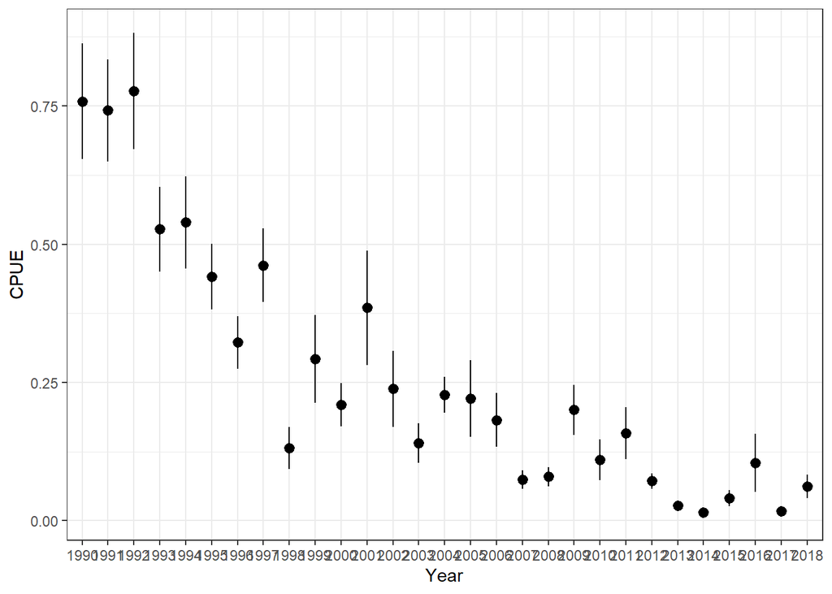

```r
ggplot(bum2,aes(x=Year,y=CPUE))+
  stat_summary()
```

```r
lnorm.mean=function(x1,x1e) {
  exp(x1+0.5*x1e^2)
}

lnorm.se=function(x1,x1e) {
  ((exp(x1e^2)-1)*exp(2*x1+x1e^2))^0.5
}
lo.se=function(x1,x1e,x2,x2e) {
  if(length(x1[!is.na(x1) &!is.na(x2)])>1 & length(unique(x1))>1 & length(unique(x2))>1 )
   cor12=cor(x1[!is.na(x1) &!is.na(x2)],x2[!is.na(x1) &!is.na(x2)]) else cor12=0
  (x1e^2 * x2^2 +x2e^2*x1^2+2*x1*x2*cor12*x1e*x2e)^0.5
}
```

Part 1. binomial

```r
BinomFit<-glmmTMB(present~(Year+season+hbf)^2,
                  data=bum2,
                  family="binomial",
                na.action = "na.fail")
BinDredge<-dredge(BinomFit,rank = "BIC")
```

```
## Fixed terms are "cond((Int))" and "disp((Int))"
```

```r
head(BinDredge)
```

```
## Global model call: glmmTMB(formula = present ~ (Year + season + hbf)^2, data = bum2,
##     family = "binomial", na.action = "na.fail", ziformula = ~0,
##     dispformula = ~1)
## ---
## Model selection table
##    cnd((Int)) dsp((Int)) cnd(hbf) cnd(ssn) cnd(Yer) cnd(hbf:ssn) df   logLik
## 4     1.23300          +  0.03894        +                        5 -591.447
## 3     1.85800          +                 +                        4 -602.916
## 12    0.84220          +  0.06645        +                     +  8 -589.369
## 8     2.32800          +  0.03874        +        +              33 -530.231
## 2    -0.08169          +  0.04232                                 2 -641.085
## 7     2.94800          +                 +        +              32 -539.785
##       BIC delta weight
## 4  1217.4  0.00  0.999
## 3  1233.5 16.03  0.000
## 12 1234.0 16.57  0.000
## 8  1288.4 70.99  0.000
## 2  1296.0 78.55  0.000
## 7  1300.6 83.18  0.000
## Models ranked by BIC(x)
```

```r
BinBest<-get.models(BinDredge,subset=1)[[1]]
summary(BinBest)
```

```
##  Family: binomial  ( logit )
## Formula:          present ~ hbf + season + 1
## Data: bum2
##
##       AIC       BIC    logLik -2*log(L)  df.resid
##    1192.9    1217.4    -591.4    1182.9       995
##
##
## Conditional model:
##              Estimate Std. Error z value Pr(>|z|)
## (Intercept)  1.233218   0.222566   5.541 3.01e-08 ***
## hbf          0.038943   0.008192   4.754 2.00e-06 ***
## season2     -1.547734   0.226176  -6.843 7.75e-12 ***
## season3     -2.068711   0.232364  -8.903  < 2e-16 ***
## season4     -1.210910   0.224318  -5.398 6.73e-08 ***
## ---
## Signif. codes:  0 '***' 0.001 '**' 0.01 '*' 0.05 '.' 0.1 ' ' 1
```

```
## DHARMa:testOutliers with type = binomial may have inflated Type I error rates for integer-valued distributions. To get a more exact result, it is recommended to re-run testOutliers with type = 'bootstrap'. See ?testOutliers for details
```

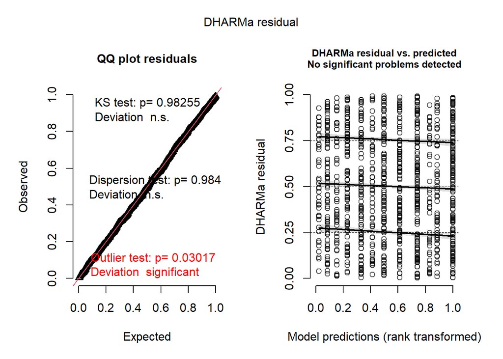

```r
plot(simulateResiduals(BinBest))
```

Residuals look fine. Best model has hbf and season.

Part 2. log(CPUE) positive only

```r
posdat<-filter(bum2,present==1)
cpueFit<-glmmTMB(log(CPUE)~(Year+season+hbf)^2,
                  data=posdat,
                  family="gaussian",
                na.action = "na.fail")
```

```
## dropping columns from rank-deficient conditional model: Year2000:season3, Year2005:season3, Year2015:season3, Year2017:season4
```

```r
cpueDredge<-dredge(cpueFit,rank = "BIC")
```

```
## Fixed terms are "cond((Int))" and "disp((Int))"
```

```
## dropping columns from rank-deficient conditional model: season3:Year2000, season3:Year2005, season3:Year2015, season4:Year2017
```

```
## dropping columns from rank-deficient conditional model: season3:Year2000, season3:Year2005, season3:Year2015, season4:Year2017
## dropping columns from rank-deficient conditional model: season3:Year2000, season3:Year2005, season3:Year2015, season4:Year2017
## dropping columns from rank-deficient conditional model: season3:Year2000, season3:Year2005, season3:Year2015, season4:Year2017
```

```
## dropping columns from rank-deficient conditional model: season3:Year2000, season3:Year2005, season3:Year2015, season4:Year2017
```

```r
head(cpueDredge)
```

```
## Global model call: glmmTMB(formula = log(CPUE) ~ (Year + season + hbf)^2, data = posdat,
##     family = "gaussian", na.action = "na.fail", ziformula = ~0,
##     dispformula = ~1)
## ---
## Model selection table
##    cnd((Int)) dsp((Int)) cnd(hbf) cnd(ssn) cnd(Yer) cnd(hbf:ssn) df   logLik
## 8     -0.7560          +  0.02636        +        +              34 -788.841
## 16    -0.5271          +  0.01069        +        +            + 37 -780.341
## 7     -0.2745          +                 +        +              33 -807.762
## 6     -0.8921          +  0.02729                 +              31 -816.360
## 5     -0.4173          +                          +              30 -835.111
## 4     -1.6470          +  0.03564        +                        6 -919.039
##       BIC delta weight
## 8  1797.1  0.00  0.765
## 16 1799.5  2.36  0.235
## 7  1828.5 31.39  0.000
## 6  1832.8 35.68  0.000
## 5  1863.8 66.73  0.000
## 4  1876.8 79.70  0.000
## Models ranked by BIC(x)
```

```r
cpueBest<-get.models(cpueDredge,subset=1)[[1]]
summary(cpueBest)
```

```
##  Family: gaussian  ( identity )
## Formula:          log(CPUE) ~ hbf + season + Year + 1
## Data: posdat
##
##       AIC       BIC    logLik -2*log(L)  df.resid
##    1645.7    1797.1    -788.8    1577.7       601
##
##
## Dispersion estimate for gaussian family (sigma^2): 0.702
##
## Conditional model:
##              Estimate Std. Error z value Pr(>|z|)
## (Intercept) -0.756039   0.166278  -4.547 5.45e-06 ***
## hbf          0.026363   0.004222   6.245 4.25e-10 ***
## season2      0.170267   0.093473   1.822  0.06852 .
## season3     -0.481653   0.108815  -4.426 9.58e-06 ***
## season4     -0.416731   0.087323  -4.772 1.82e-06 ***
## Year1991    -0.007740   0.191127  -0.040  0.96770
## Year1992     0.065175   0.211615   0.308  0.75809
## Year1993    -0.349957   0.195932  -1.786  0.07408 .
## Year1994    -0.259636   0.190252  -1.365  0.17235
## Year1995    -0.531589   0.196994  -2.699  0.00697 **
## Year1996    -0.467193   0.201288  -2.321  0.02029 *
## Year1997    -0.495033   0.205464  -2.409  0.01598 *
## Year1998    -1.045946   0.240199  -4.354 1.33e-05 ***
## Year1999    -0.662531   0.232845  -2.845  0.00444 **
## Year2000    -1.008375   0.215595  -4.677 2.91e-06 ***
## Year2001    -1.013366   0.235493  -4.303 1.68e-05 ***
## Year2002    -1.042427   0.259686  -4.014 5.97e-05 ***
## Year2003    -1.299083   0.222097  -5.849 4.94e-09 ***
## Year2004    -1.193067   0.209245  -5.702 1.19e-08 ***
## Year2005    -0.690554   0.329878  -2.093  0.03632 *
## Year2006    -1.213068   0.235218  -5.157 2.51e-07 ***
## Year2007    -1.644254   0.237250  -6.930 4.19e-12 ***
## Year2008    -1.639884   0.236206  -6.943 3.85e-12 ***
## Year2009    -0.995445   0.248010  -4.014 5.98e-05 ***
## Year2010    -1.138099   0.272862  -4.171 3.03e-05 ***
## Year2011    -1.499316   0.239514  -6.260 3.85e-10 ***
## Year2012    -1.959548   0.230834  -8.489  < 2e-16 ***
## Year2013    -1.937776   0.328791  -5.894 3.78e-09 ***
## Year2014    -2.063724   0.371411  -5.556 2.75e-08 ***
## Year2015    -1.678323   0.347797  -4.826 1.40e-06 ***
## Year2016    -1.448164   0.314183  -4.609 4.04e-06 ***
## Year2017    -2.043245   0.402543  -5.076 3.86e-07 ***
## Year2018    -1.672846   0.314694  -5.316 1.06e-07 ***
## ---
## Signif. codes:  0 '***' 0.001 '**' 0.01 '*' 0.05 '.' 0.1 ' ' 1
```

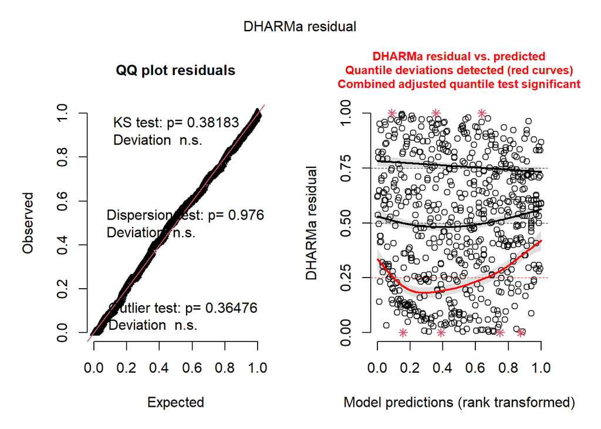

```r
plot(simulateResiduals(cpueBest))
```

Calculate index

```r
newdata3<-expand.grid(Year=factor(levels(bum2$Year)),
                    season=factor("1"),
                    hbf=mean(bum2$hbf),
                    sets=1)  #1 set to get CPUE
temp<-predict(BinBest,
              newdata = newdata3,
              se.fit = TRUE,
              type="response")
newdata3$binomial<-temp$fit
newdata3$binomial.se<-temp$se.fit
temp<-predict(cpueBest,
              newdata = newdata3,
              se.fit = TRUE) #response is on log scale
#lognormal conversion functions to get mean if positive
newdata3$pos.cpue<-lnorm.mean(temp$fit,temp$se.fit)
newdata3$pos.cpue.se<-lnorm.se(temp$fit,temp$se.fit)
#index
newdata3<-newdata3 %>%
  mutate(fit=binomial*pos.cpue,
         se=lo.se(binomial,binomial.se,pos.cpue,pos.cpue.se))
head(newdata3)
```

```
##   Year season    hbf sets  binomial binomial.se  pos.cpue pos.cpue.se       fit
## 1 1990      1 15.425    1 0.8622275  0.02206652 0.7128669  0.10594351 0.6146534
## 2 1991      1 15.425    1 0.8622275  0.02206652 0.7063183  0.09748269 0.6090071
## 3 1992      1 15.425    1 0.8622275  0.02206652 0.7626295  0.12485599 0.6575601
## 4 1993      1 15.425    1 0.8622275  0.02206652 0.5023064  0.07420887 0.4331023
## 5 1994      1 15.425    1 0.8622275  0.02206652 0.5489978  0.07546454 0.4733610
## 6 1995      1 15.425    1 0.8622275  0.02206652 0.4189263  0.06222936 0.3612098
##           se
## 1 0.09269194
## 2 0.08548511
## 3 0.10896165
## 4 0.06493789
## 5 0.06618574
## 6 0.05444637
```

Compare fits

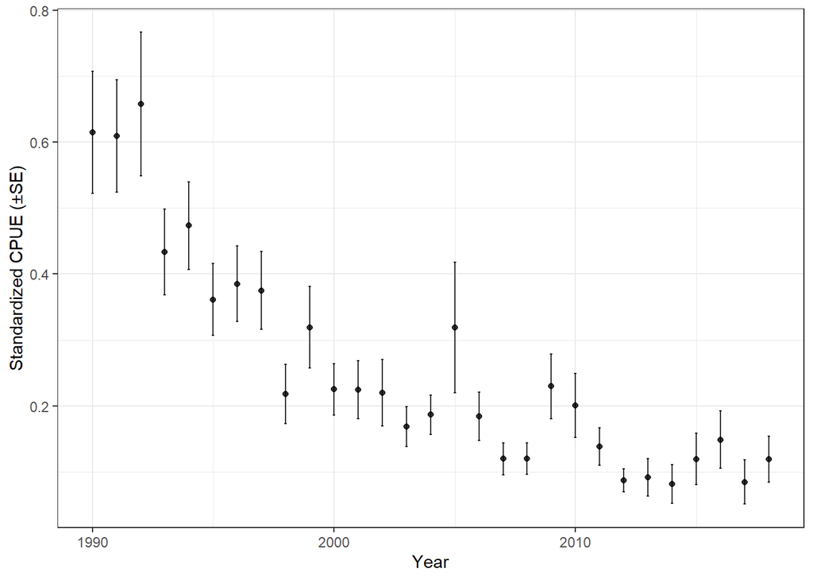

```r
ggplot(newdata3,aes(x=as.numeric(as.character(Year)),y=fit,ymin=fit-se,
           ymax=fit+se))+
  geom_point(alpha=0.8)+
  geom_errorbar(width=0.1,alpha=0.8)+
  labs(x="Year",
    y="Standardized CPUE (±SE)")
```